# I/O and hyperlinks, data and descriptives

## Load I/O data

These are the industry codes. To begin with, we start with the total of all sectors. We can talk at a later stage about different sectors.

| Code | Industry name |
| --- | --- |
| ss1 | Agriculture |
| ss2 | Mining_quarrying_and_energy_supply |
| ss3 | Food_beverages_and_tobacco |
| ss4 | Textiles_and_leather_etc |
| ss5 | Coke_refined_petroleum_nuclear_fuel_and_chemicals_etc |
| ss6 | Electrical_and_optical_equipment_and_Transport_equipment |
| ss8 | Other_manufacturing |
| ss9 | Construction |
| ss10 | Distribution |
| ss11 | Hotels_and_restaurant |
| ss12 | Transport_storage_and_communication |
| ss13 | Financial_intermediation |
| ss14 | Real_estate_renting_and_busine_activitie |
| ss15 | Non-Market_Service |

## Hyperlink data

These region-to-region flows represent the number of hyperlinks between two regions. These are hyperlinks between commercial websites that is websites under the .co.uk Second Level Domain (SLD). Also, we only consider commercial website that contain one unique UK postcode in the text.

## Distance

I calculate the distance between NUTS2 centroids. **TODO**: check if it is spherical distance

## GVA

Adding yearly GVA data to capture market size.

## Population

```r
# library(eurostat)

# tf <- tempfile(fileext = ".xlsx")
# download.file(url = 'https://ec.europa.eu/eurostat/documents/345175/629341/NUTS2013-NUTS2016.xlsx', destfile = tf,  mode = 'wb'  )

# pop <- get_eurostat(id = "demo_r_d2jan", select_time = "Y") %>%
#   filter(grepl("UK", geo)) %>%
#   filter(sex=="T") %>%
#   mutate(nuts.type=str_length(geo)) %>%
#   filter(nuts.type==4) %>%
#   mutate(year=as.numeric(str_sub(time, start = 1, end = 4))) %>%
#   filter(year > 1999 & year <2011) %>%
#   harmonize_geo_code()

file <- "./data/other/UK pop_EUREGIO.xlsx"
pop <- read_excel(file, col_names = T)

pop <- pop %>%
  mutate(emp_thousands = as.numeric(emp_thousands),
         pop_total = as.numeric(pop_total),
         pop_density = as.numeric(pop_density),
         code = as.factor(code))
sapply(pop, function(x) sum(is.na(x)))
```

```
##          code        number          year          name emp_thousands
##             0             0             0             0            12
##     pop_total   pop_density
##            26            26
```

```r
# impute with means
library(imputeTS)
pop <- na_mean(pop) # replaces with mean of all observations

pop$code <- gsub("UKD2", "UKD6", pop$code)
pop$code <- gsub("UKD5", "UKD7", pop$code)


# merge
total <- merge(total, pop, by.x = c("orig", "year"), by.y = c("code", "year"), all.x = T)
#sapply(total, function(x) sum(is.na(x)))
total <- total %>%
  rename(emp_thousands.orig = emp_thousands,
         pop_total.orig = pop_total,
         pop_density.orig = pop_density) %>%
  dplyr::select(-c(number, name))

total <- merge(total, pop, by.x = c("dest", "year"), by.y = c("code", "year"), all.x = T)
#sapply(total, function(x) sum(is.na(x)))
total <- total %>%
  rename(emp_thousands.dest = emp_thousands,
         pop_total.dest = pop_total,
         pop_density.dest = pop_density) %>%
  dplyr::select(-c(number, name))
```

## Node centralities

I calculate simple weighted centrality for the NUTS2 regions based on the hyperlinks. This represents the volume of all incoming and outgoing hyperlinks for each region. **TODO**: does it make sense to bring other network variables? Please note that this is an aggregated network of hyperlink flows between regions and not a network of individual (website-to-website) flows.

## Descriptive statistics

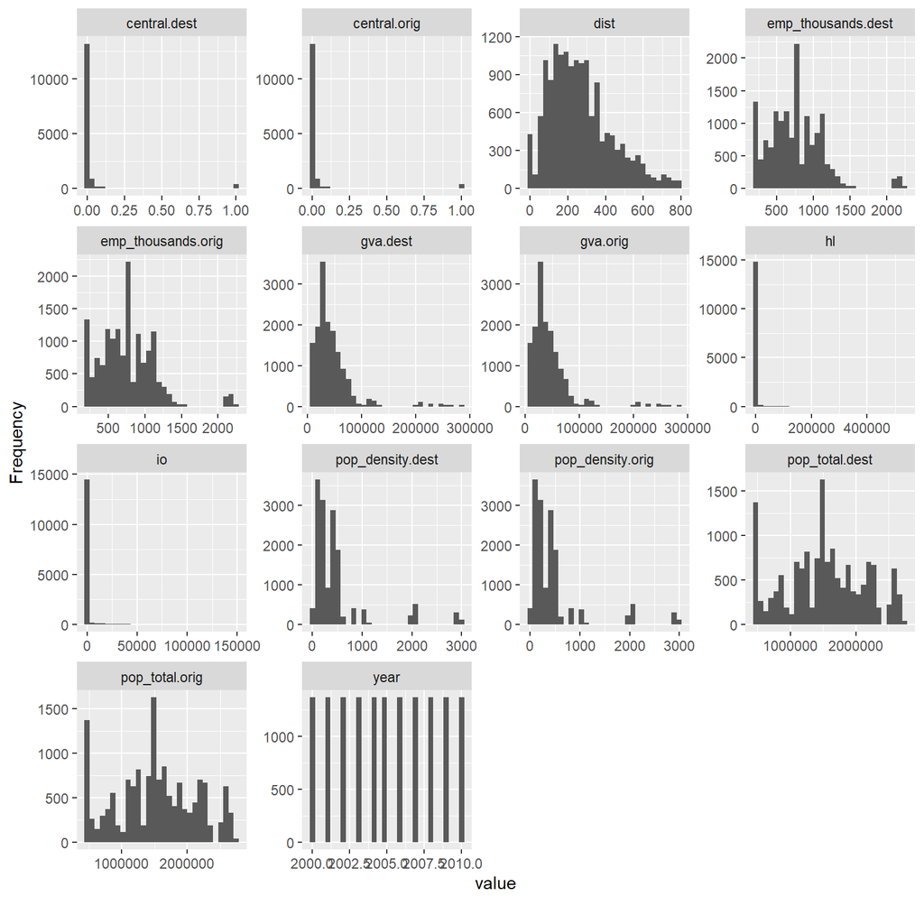

Table: Data summary

| Name | total |
| --- | --- |
| Number of rows | 15059 |
| Number of columns | 17 |
| _______________________ |  |
| Column type frequency: |  |
| factor | 3 |
| numeric | 14 |
| ________________________ |  |
| Group variables |  |

**Variable type: factor**

| skim_variable | n_missing | complete_rate | ordered | n_unique | top_counts |
| --- | --- | --- | --- | --- | --- |
| dest | 0 | 1 | FALSE | 37 | UKC: 407, UKC: 407, UKD: 407, UKD: 407 |
| orig | 0 | 1 | FALSE | 37 | UKC: 407, UKC: 407, UKD: 407, UKD: 407 |
| id | 0 | 1 | FALSE | 1369 | UKC: 11, UKC: 11, UKC: 11, UKC: 11 |

**Variable type: numeric**

| skim_variable | n_missing | complete_rate | mean | sd | p0 | p25 | p50 | p75 | p100 | hist |
| --- | --- | --- | --- | --- | --- | --- | --- | --- | --- | --- |
| year | 0 | 1 | 2005.00 | 3.16 | 2000.00 | 2002.00 | 2005.00 | 2008.00 | 2010.00 | ▇▅▅▅▅ |
| io | 0 | 1 | 918.71 | 5012.78 | 0.02 | 75.95 | 179.54 | 353.46 | 149015.44 | ▇▁▁▁▁ |
| hl | 0 | 1 | 639.97 | 7166.65 | 0.00 | 2.00 | 15.00 | 68.00 | 534958.00 | ▇▁▁▁▁ |
| dist | 0 | 1 | 266.22 | 165.89 | 0.00 | 141.25 | 238.50 | 352.68 | 789.76 | ▆▇▃▂▁ |
| gva.orig | 0 | 1 | 45146.26 | 39241.41 | 7386.48 | 25005.89 | 35101.75 | 53912.40 | 282187.65 | ▇▁▁▁▁ |
| gva.dest | 0 | 1 | 45146.26 | 39241.41 | 7386.48 | 25005.89 | 35101.75 | 53912.40 | 282187.65 | ▇▁▁▁▁ |
| emp_thousands.orig | 0 | 1 | 755.15 | 374.26 | 188.00 | 501.80 | 749.90 | 960.10 | 2224.50 | ▇▇▃▁▁ |
| pop_total.orig | 0 | 1 | 1513563.17 | 610857.51 | 433756.00 | 1107973.00 | 1513563.17 | 1969549.00 | 2709001.00 | ▅▅▇▅▃ |
| pop_density.orig | 0 | 1 | 467.64 | 590.11 | 10.70 | 146.20 | 299.80 | 467.64 | 3008.60 | ▇▁▁▁▁ |
| emp_thousands.dest | 0 | 1 | 755.15 | 374.26 | 188.00 | 501.80 | 749.90 | 960.10 | 2224.50 | ▇▇▃▁▁ |
| pop_total.dest | 0 | 1 | 1513563.17 | 610857.51 | 433756.00 | 1107973.00 | 1513563.17 | 1969549.00 | 2709001.00 | ▅▅▇▅▃ |
| pop_density.dest | 0 | 1 | 467.64 | 590.11 | 10.70 | 146.20 | 299.80 | 467.64 | 3008.60 | ▇▁▁▁▁ |
| central.orig | 0 | 1 | 0.04 | 0.17 | 0.00 | 0.00 | 0.00 | 0.01 | 1.00 | ▇▁▁▁▁ |
| central.dest | 0 | 1 | 0.04 | 0.17 | 0.00 | 0.00 | 0.00 | 0.01 | 1.00 | ▇▁▁▁▁ |

## Spageti plots

The IO flows are quite stable contrary to the more erratic hyperlink-based flows. In both cases, some intra-regional flows appear have the highest values.

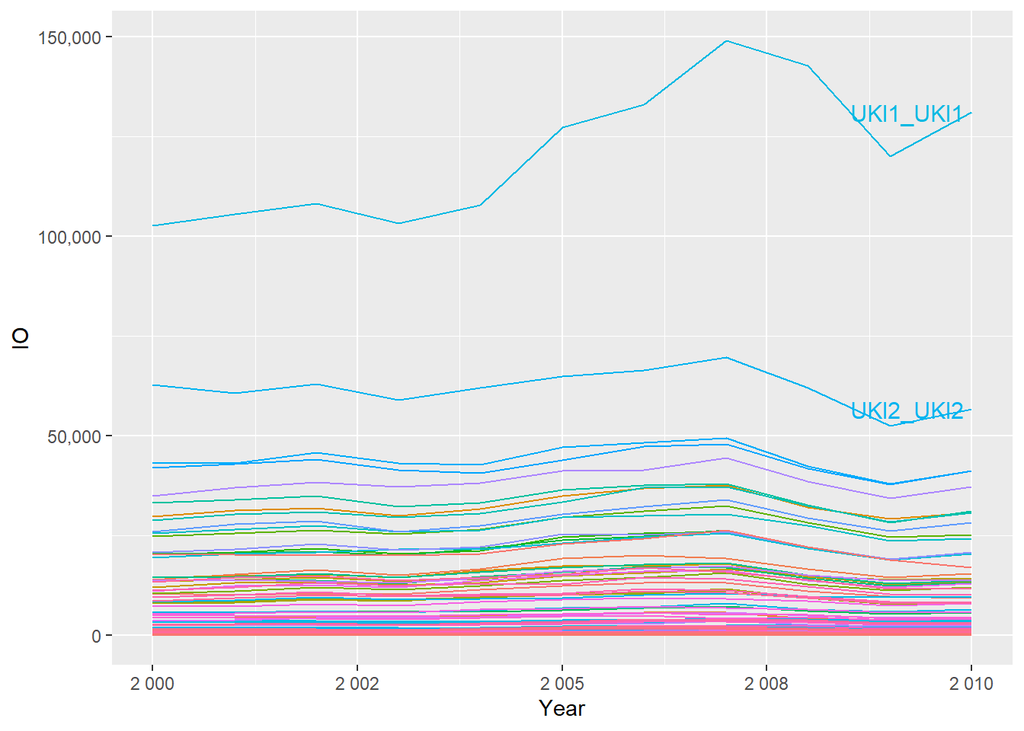

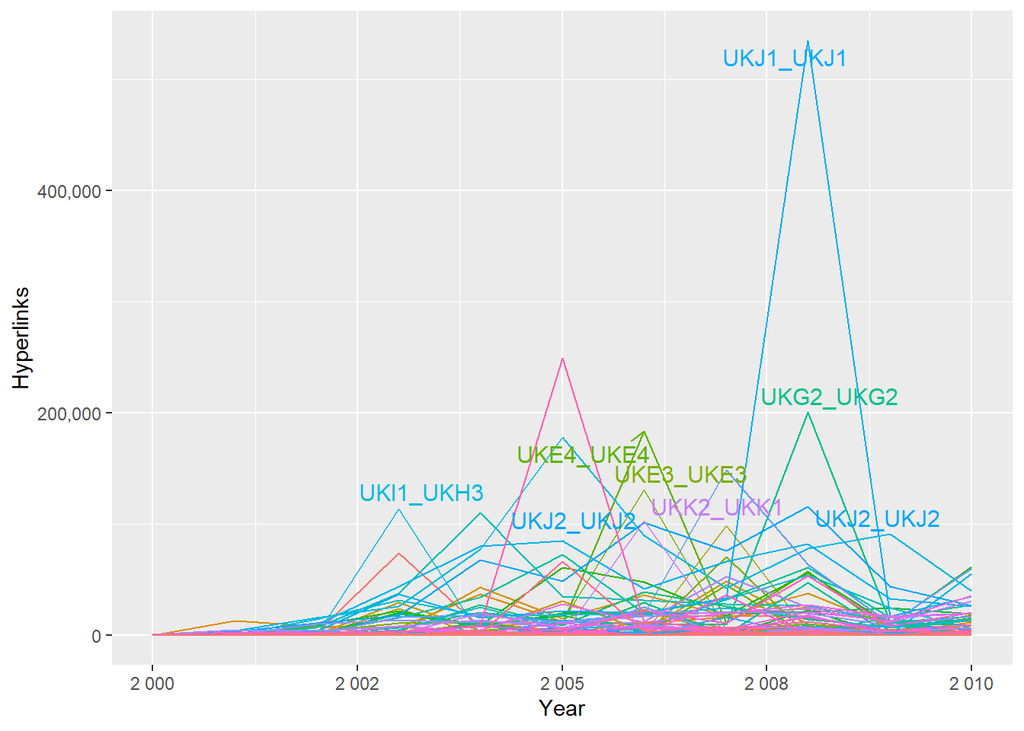

## Scatter plots with all the observations

The main hypothesis is that hyperlinks between commercial websites can capture IO flows aggregated at a regional level. **TODO:* work on the hypothesis.

[figure not shown]

## Scatter plots no outliers

I removed the following hl values: abs(hl - median(hl)) > 2*sd(hl))

[figure not shown]

## Correletions

| year | COR_io_hl |
| --- | --- |
| 2000 | 0.5386342 |
| 2001 | 0.5779548 |
| 2002 | 0.7930733 |
| 2003 | 0.4828762 |
| 2004 | 0.8067314 |
| 2005 | 0.6433527 |
| 2006 | 0.5848025 |
| 2007 | 0.5978923 |
| 2008 | 0.4909415 |
| 2009 | 0.9217370 |
| 2010 | 0.6735281 |

| year | COR_io_dist |
| --- | --- |
| 2000 | -0.2179845 |
| 2001 | -0.2194992 |
| 2002 | -0.2200102 |
| 2003 | -0.2193085 |
| 2004 | -0.2216951 |
| 2005 | -0.2173189 |
| 2006 | -0.2180505 |
| 2007 | -0.2125114 |
| 2008 | -0.2036975 |
| 2009 | -0.2057006 |
| 2010 | -0.2034701 |

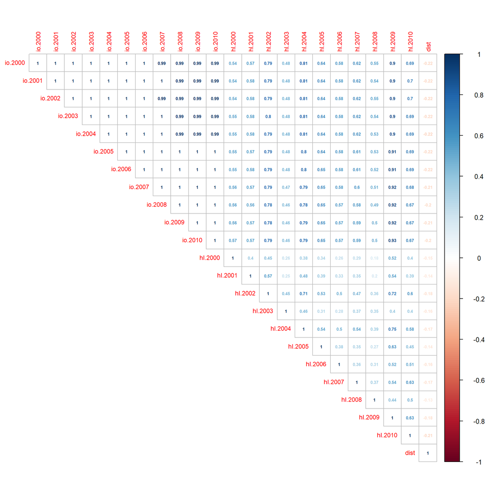

## Maps

This needs more work. **@George** let’s talk

```r
wgs84 = '+proj=longlat +datum=WGS84'
nuts.shp <- spTransform(nuts.shp, CRS(wgs84))

# select a subset with flows
total_flows <- select(total, orig, dest, hl, io, year)
total_flows <-od2line(flow = total_flows, zones = nuts.shp, zone_code = "NUTS_ID")

# We transform the new spatial object to WGS84.
total_flows <- spTransform(total_flows, CRS(wgs84))


Flow_pal <- colorQuantile("YlOrBr", domain = total_flows$hl, n=5)

leaflet() %>%
  addTiles() %>%
  addPolylines(
    data = total_flows,
    weight = 1, # Notice the different value for better visual effect when zoom in
    color = ~Flow_pal(hl),
    opacity = .8, # as above
    group = total_flows$year) %>%
  addLayersControl(
    position = "bottomleft",
    overlayGroups = unique(total_flows$year),
    options = layersControlOptions(collapsed = FALSE)) %>%
  addLegend("topright",
          pal = Flow_pal,
          values = total_flows$hl,
          title = "hl")
```

[interactive chart not shown]